# Tree Phenology Assignment

# 28 Chapter 31: The PhenoFlex model - a second look

## 28.1 *Exercises on basic PhenoFlex diagnostics*

1. Make chill and heat response plots for the ‘Roter Boskoop’ PhenoFlex model for the location you did the earlier analyses for.

```r
library(tidyverse)
library(chillR)

Roter_par <-
  read_tab("C:/Users/Home/Documents/R Files/Trial Bookdown/data_New_York/PhenoFlex_parameters_Roter_Boskoop.csv")[,2]

E0 <- Roter_par[5]
E1 <- Roter_par[6]
A0 <- Roter_par[7]
A1 <- Roter_par[8]
Tf <- Roter_par[9]
slope <- Roter_par[12]

apply_const_temp <-
  function(temp,
           A0, A1, E0, E1, Tf,
           slope, portions = 1200, deg_celsius = TRUE) {
    temp_vector <- rep(temp,
                       times = portions)
    res <- chillR::DynModel_driver(temp = temp_vector,
                                   A0 = A0,
                                   A1 = A1,
                                   E0 = E0,
                                   E1 = E1,
                                   Tf = Tf,
                                   slope = slope,
                                   deg_celsius = deg_celsius)
    return(res$y[length(res$y)])
  }

apply_const_temp(4, A0, A1, E0, E1, Tf,
                 slope)
```

```
## [1] 16.82839
```

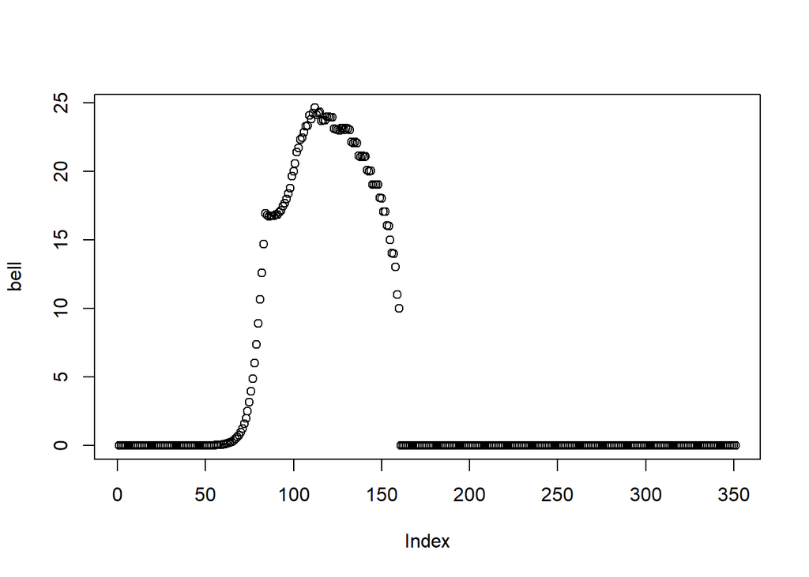

```r
gen_bell <- function(par,
                     temp_values = seq(-5, 20, 0.1)) {
  E0 <- par[5]
  E1 <- par[6]
  A0 <- par[7]
  A1 <- par[8]
  Tf <- par[9]
  slope <- par[12]

  y <- c()
  for(i in seq_along(temp_values)) {
    y[i] <- apply_const_temp(temp = temp_values[i],
                             A0 = A0,
                             A1 = A1,
                             E0 = E0,
                             E1 = E1,
                             Tf = Tf,
                             slope = slope)
  }
  return(invisible(y))
}

temp_values = seq(-5, 30, 0.1)

bell <- gen_bell(Roter_par,
                 temp_values)

plot(bell)
```

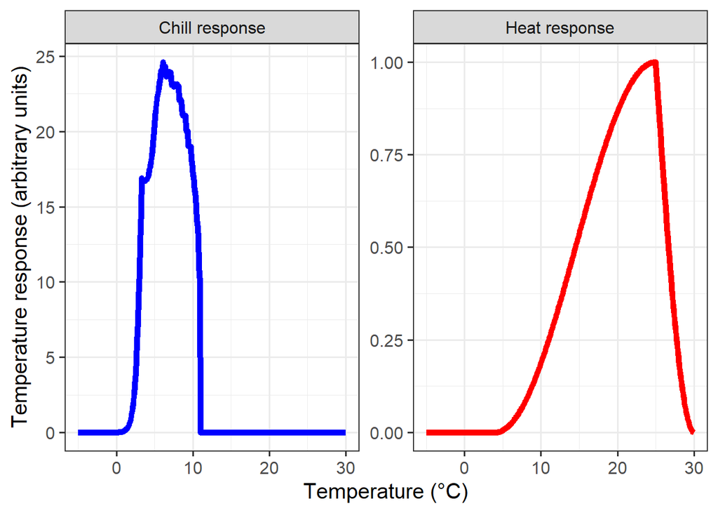

```r
GDH_response <- function(T, par) {
  Tb <- par[11]
  Tu <- par[4]
  Tc <- par[10]
  GDH_weight <- rep(0, length(T))
  GDH_weight[which(T >= Tb & T <= Tu)] <-
    1/2 * (1 + cos(pi + pi * (T[which(T >= Tb & T <= Tu)] - Tb)/(Tu - Tb)))
  GDH_weight[which(T > Tu & T <= Tc)] <-
    (1 + cos(pi/2 + pi/2 * (T[which(T >  Tu & T <= Tc)] -Tu)/(Tc - Tu)))
  return(GDH_weight)
}




temp_values = seq(-5, 30, 0.1)

temp_response <-
  data.frame(Temperature = temp_values,
             Chill_response = gen_bell(Roter_par,
                                       temp_values),
             Heat_response = GDH_response(temp_values,
                                          Roter_par))

pivoted_response <- pivot_longer(temp_response,
                                 c(Chill_response,
                                   Heat_response))

ggplot(pivoted_response,
       aes(x = Temperature,
           y = value)) +
  geom_line(linewidth = 2,
            aes(col = name)) +
  ylab("Temperature response (arbitrary units)") +
  xlab("Temperature (°C)") +
  facet_wrap(vars(name),
             scales = "free",
             labeller =
               labeller(name = c(Chill_response = c("Chill response"),
                                     Heat_response = c("Heat response")))) +
  scale_color_manual(values = c("Chill_response" = "blue",
                                "Heat_response" = "red")) +
  theme_bw(base_size = 15) +
  theme(legend.position = "none")
```

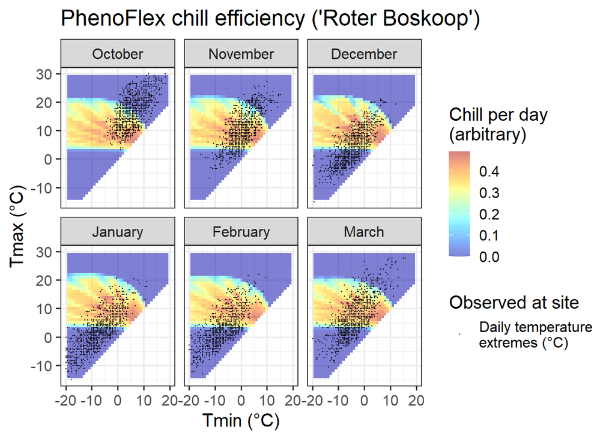

```r
# Using Rochester as location
latitude <- 43.1

month_range <- c(10, 11, 12, 1, 2, 3)

Tmins = c(-20:20)
Tmaxs = c(-15:30)

mins <- NA
maxs <- NA
chill_eff <- NA
heat_eff <- NA
month <- NA

Roter_par <- read_tab("C:/Users/Home/Documents/R Files/Trial Bookdown/data_New_York/PhenoFlex_parameters_Roter_Boskoop.csv")[, 2]

simulation_par <- Roter_par

for (mon in month_range) {
    days_month <- as.numeric(difftime(ISOdate(2002, mon + 1, 1), ISOdate(2002, mon,
        1)))
    if (mon == 12)
        days_month <- 31
    weather <- make_all_day_table(data.frame(Year = c(2002, 2002), Month = c(mon,
        mon), Day = c(1, days_month), Tmin = c(0, 0), Tmax = c(0, 0)))

    for (tmin in Tmins) for (tmax in Tmaxs) if (tmax >= tmin) {
        hourtemps <- weather %>%
            mutate(Tmin = tmin, Tmax = tmax) %>%
            stack_hourly_temps(latitude = latitude) %>%
            pluck("hourtemps", "Temp")

        chill_eff <- c(chill_eff, PhenoFlex(temp = hourtemps, times = c(1:length(hourtemps)),
            A0 = simulation_par[7], A1 = simulation_par[8], E0 = simulation_par[5],
            E1 = simulation_par[6], Tf = simulation_par[9], slope = simulation_par[12],
            deg_celsius = TRUE, basic_output = FALSE)$y[length(hourtemps)]/(length(hourtemps)/24))

        heat_eff <- c(heat_eff, cumsum(GDH_response(hourtemps, simulation_par))[length(hourtemps)]/(length(hourtemps)/24))
        mins <- c(mins, tmin)
        maxs <- c(maxs, tmax)
        month <- c(month, mon)
    }
}

results <- data.frame(Month = month, Tmin = mins, Tmax = maxs, Chill_eff = chill_eff,
    Heat_eff = heat_eff) %>%
    filter(!is.na(Month))

write.csv(results, "C:/Users/Home/Documents/R Files/Trial Bookdown/data_New_York/model_sensitivity_PhenoFlex_Roter.csv")

# Chill response plot
Model_sensitivities_PhenoFlex <- read.csv("C:/Users/Home/Documents/R Files/Trial Bookdown/data_New_York/model_sensitivity_PhenoFlex_Roter.csv")

Rochester_weather <- read_tab("C:/Users/Home/Documents/R Files/Trial Bookdown/data_New_York/Rochester_weather.csv")


Chill_sensitivity_temps(Model_sensitivities_PhenoFlex, Rochester_weather, temp_model = "Chill_eff",
    month_range = c(10, 11, 12, 1, 2, 3), Tmins = c(-20:20), Tmaxs = c(-15:30), legend_label = "Chill per day \n(arbitrary)") +
    ggtitle("PhenoFlex chill efficiency ('Roter Boskoop')")
```

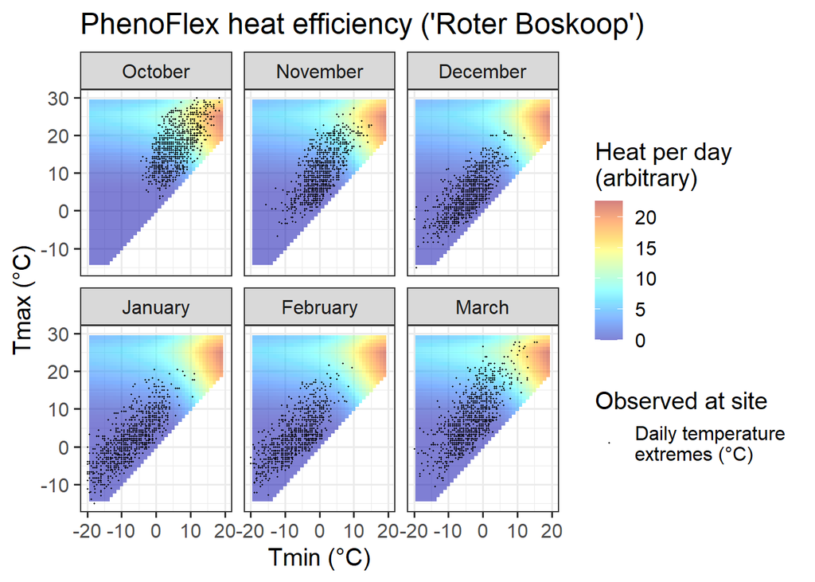

```r
# Heat response plot
Chill_sensitivity_temps(Model_sensitivities_PhenoFlex, Rochester_weather, temp_model = "Heat_eff",
    month_range = c(10, 11, 12, 1, 2, 3), Tmins = c(-20:20), Tmaxs = c(-15:30), legend_label = "Heat per day \n(arbitrary)") +
    ggtitle("PhenoFlex heat efficiency ('Roter Boskoop')")
```

# 29 Chapter 32: Can we improve the performance of PhenoFlex

## 29.1 *Exercises on improving the performance of PhenoFlex*

Describe (briefly) in your own words:

1. What was the objective of this work? The objective is to validate the PhenoFlex model under different conditions. Also, some results obtained in the original publication suggest temperature responses during chill accumulation that seem implausible.
2. What was the main conclusion? Discussions on the major potential limitations of the PhenoFlex and other models. It has been obbserved that under extreme conditions, the process of dormancy breaking is modulated by mechanisms that are not considered in the PhenoFlex framework.
3. What experiments could we conduct to test the hypothesis that emerged at the end of the conclusion? It has been concluded that additional systematic studies would have to be conducted.

# 30 Chapter 33: Frost risk analysis

## 30.1 *Exercises on frost risk analysis*

1.Download the phenology dataset for the apple cultivar Roter Boskoop from Klein-Altendorf.

```r
library(chillR)
library(tidyverse)
library(kableExtra)

CKA_Roter_Boskoop <- read_tab("C:/Users/Home/Documents/R Files/Trial Bookdown/data_New_York/Roter_Boskoop_bloom_1958_2019.csv.csv")


Roter_Boskoop <- CKA_Roter_Boskoop %>%
  pivot_longer(cols = "First_bloom":"Last_bloom",
               names_to = "variable",
               values_to="YEARMODA") %>%
  mutate(Year = as.numeric(substr(YEARMODA, 1, 4)),
         Month = as.numeric(substr(YEARMODA, 5, 6)),
         Day = as.numeric(substr(YEARMODA, 7, 8))) %>%
  make_JDay()
```

2.Illustrate the development of the bloom period over the duration of the weather record. Use multiple ways to show this - feel free to be creative.

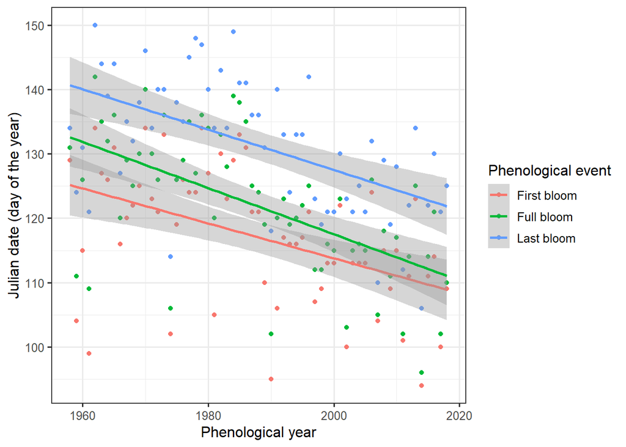

```r
# Illustrating with a scatter plot
library(chillR)
library(tidyverse)
library(kableExtra)

ggplot(data = Roter_Boskoop,aes(Pheno_year, JDay, col = variable)) +
  geom_point() +
  geom_smooth(method=lm) +
  theme_bw(base_size=12) +
  scale_color_discrete(
    name = "Phenological event",
    labels = c("First bloom", "Full bloom", "Last bloom")) +
  xlab("Phenological year") +
  ylab("Julian date (day of the year)")
```

3. Evaluate the occurrence of frost events at Klein-Altendorf since 1958. Illustrate this in a plot.

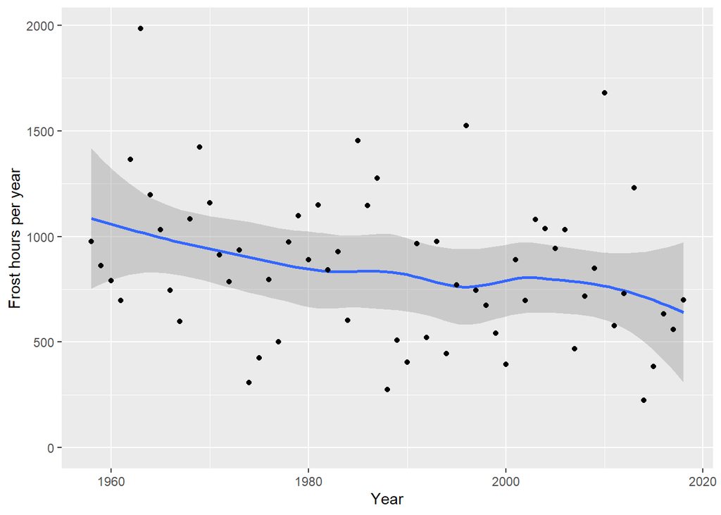

```r
library(chillR)
library(tidyverse)
library(kableExtra)

# Generating model for frost hours (temperatures < 0°C)
frost_df = data.frame(
  lower = c(-1000, 0),
  upper = c(0, 1000),
  weight = c(1, 0))

frost_model <- function(x) step_model(x,
                                      frost_df)

# Convert temperature record to hourly values
hourly <- stack_hourly_temps(CKA_weather,
                             latitude = 50.625)

frost <- tempResponse(hourly,
                      models = c(frost = frost_model))

# Plot number of frost hours
ggplot(frost,
       aes(End_year,
           frost)) +
  geom_smooth() +
  geom_point() +
  ylim(c(0, NA)) +
  ylab("Frost hours per year") +
  xlab("Year")
```

4. Produce an illustration of the relationship between spring frost events and the bloom period of ‘Roter Boskoop’.

```r
# library(chillR)
# library(leaflet)
# library(tidyverse)
# library(kableExtra)
# library(Kendall)
#
# # Generating model for frost hours (temperatures < 0°C)
# frost_df = data.frame(
#   lower = c(-1000, 0),
#   upper = c(0, 1000),
#   weight = c(1, 0))
#
# frost_model <- function(x) step_model(x,
#                                       frost_df)
#
# # Convert temperature record to hourly values
# hourly <- stack_hourly_temps(CKA_weather,
#                              latitude = 50.625)
#
# frost <- tempResponse(hourly,
#                       models = c(frost = frost_model))
#
#
# # Ribbon for total bloom duration
# Ribbon_Boskoop <-
#   Roter_Boskoop %>%
#   select(Pheno_year, variable, JDay) %>%
#   pivot_wider(names_from = "variable", values_from = "JDay")
#
# # Identify frost events that overlap with bloom
# lookup_dates <- Ribbon_Boskoop
#
# row.names(lookup_dates) <- lookup_dates$Pheno_year
#
# Daily_frost[, "First_bloom"]<-
#   lookup_dates[as.character(Daily_frost$Year),
#                "First_bloom"]
#
# Daily_frost[, "Last_bloom"] <-
#   lookup_dates[as.character(Daily_frost$Year),
#                "Last_bloom"]
#
# Daily_frost[which(!is.na(Daily_frost$Frost_hours)),
#             "Bloom_frost"] <-
#   "Before bloom"
#
# Daily_frost[which(Daily_frost$JDay >= Daily_frost$First_bloom),
#             "Bloom_frost"] <-
#   "During bloom"
#
# Daily_frost[which(Daily_frost$JDay > Daily_frost$Last_bloom),
#             "Bloom_frost"] <-
#   "After bloom"
#
# Daily_frost[which(Daily_frost$JDay > 180),
#             "Bloom_frost"] <-
#   "Before bloom"
# # Plot spring frost events that coincided with bloom
# ggplot(data = Ribbon_Boskoop,
#        aes(Pheno_year)) +
#   geom_ribbon(aes(ymin = First_bloom,
#                   ymax = Last_bloom),
#               fill = "light gray") +
#   geom_line(aes(y = Full_bloom)) +
#   theme_bw(base_size = 15) +
#   xlab("Phenological year") +
#   ylab("Julian date (day of the year)") +
#   geom_point(data = Daily_frost,
#              aes(Year,
#                  JDay,
#                  size = Frost_hours,
#                  col = Bloom_frost),
#              alpha = 0.8) +
#   scale_size(range = c(0, 5),
#              breaks = c(1, 5, 10, 15, 20),
#              labels = c("1", "5", "10", "15", "20"),
#              name = "Frost hours") +
#   scale_color_manual(
#     breaks = c("Before bloom",
#                "During bloom",
#                "After bloom"),
#     values = c("light green",
#                "red",
#                "light blue"),
#     name = "Frost timing") +
#   theme_bw(base_size = 15) +
#   ylim(c(75, 140))
```

5. Evaluate how the risk of spring frost for this cultivar has changed over time. Has there been a significant trend?

```r
# library(chillR)
# library(leaflet)
# library(tidyverse)
# library(kableExtra)
# library(Kendall)
#
# # Generating model for frost hours (temperatures < 0°C)
# frost_df = data.frame(
#   lower = c(-1000, 0),
#   upper = c(0, 1000),
#   weight = c(1, 0))
#
# frost_model <- function(x) step_model(x,
#                                       frost_df)
#
# # Convert temperature record to hourly values
# hourly <- stack_hourly_temps(CKA_weather,
#                              latitude = 50.625)
#
# frost <- tempResponse(hourly,
#                       models = c(frost = frost_model))
#
#
# # Investigate if there is a long-term trend in the number of frost hours during bloom
# Bloom_frost_trend <-
#   aggregate(
#     Daily_frost$Frost_hours,
#     by = list(Daily_frost$Year,
#               Daily_frost$Bloom_frost),
#     FUN = function(x) sum(x,
#                           na.rm = TRUE))
#
# colnames(Bloom_frost_trend) <- c("Year",
#                                  "Frost_timing",
#                                  "Frost_hours")
#
# DuringBloom <-
#   Bloom_frost_trend[
#     which(Bloom_frost_trend$Frost_timing == "During bloom"),]
#
# ggplot(data = DuringBloom,
#        aes(Year,
#            Frost_hours)) +
#   geom_col() +
#   ylab("Frost hours")
```